# CVSH_5: Age and Straying

# Overview

Interested in:

- age structure at program overall
- age at spawning by cohort and return year
- age at spawning by binned spawn date
- mean/median spawn dates by age and sex
- straying counts per origin/return programs

```r
library(tidyverse)
library(dplyr)
library(purrr)
library(ggplot2)
library(lubridate)
library(maps)
```

```r
cvsh <-read_rds("../processed_data/CV_pedigree.rds") # load in pedigree

# separate kid years apart so we can calculate age for each year they spawned
age <- cvsh %>%
  separate_rows(kid_year) %>%
  mutate(age_spawn = as.numeric(kid_year)-as.numeric(SpawnYear))
```

# Age Structure by Program

## Overall

```r
age_pro <- age %>%
  group_by(PopName) %>%
  count(age_spawn) %>%
  mutate(total = sum(n), freq = n/sum(n))

age_pro_234 <- age %>%
  group_by(PopName) %>%
  count(age_spawn) %>%
  filter(age_spawn <5) %>%
  mutate(total = sum(n), freq = n/sum(n))
```

Kruskal-wallis: age_spawn by program

```r
options(digits = 7)
kruskal.test(age_pro, age_spawn~PopName)
```

```
    Kruskal-Wallis rank sum test

data:  age_pro
Kruskal-Wallis chi-squared = 65.248, df = 4, p-value
= 2.282e-13
```

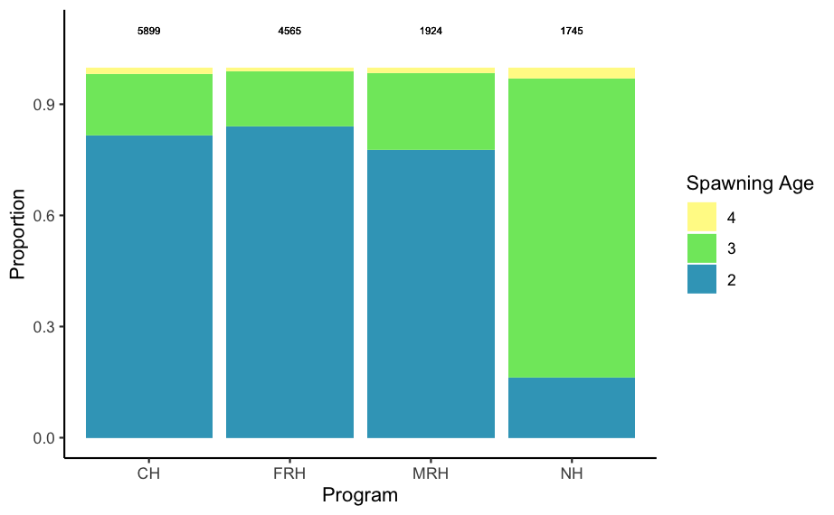

```r
age_pro_gg <- ggplot(age_pro_234 %>% filter(age_spawn <5))+
  geom_col(aes(x=PopName, y=freq, fill = as.factor(age_spawn)),
           position = position_fill(reverse = TRUE))+
  scale_fill_manual(values = c("#39a5c2","#7ee76c","#fff995"))+
  theme_classic()+
  guides(fill = guide_legend(reverse = TRUE, title="Spawning Age"))+
  labs(x="Program", y="Proportion")+
  geom_text(aes(label=total, x=PopName, y=1.1), size = 2)
age_pro_gg
```

## By Program and Sex

```r
age_sex_pro <- age %>%
  group_by(PopName, kid_sex) %>%
  count(age_spawn) %>%
  mutate(total = sum(n), freq = n/sum(n))%>%
  dplyr::mutate_if(is.numeric, round, 3) %>%
  mutate(final_col = paste(n, " (", (freq*100), "%)", sep="")) %>%
  select(PopName, age_spawn, kid_sex, final_col) %>%
  pivot_wider(names_from = PopName, values_from = final_col) %>%
  replace_na(list(CH = "0", FRH = "0", MRH = "0", NH = "0"))
```

```
`mutate_if()` ignored the following grouping variables:
```

```r
write_csv(age_sex_pro, "../tables/3_age_sex.csv")

age_sex_234 <- age %>%
  group_by(PopName, kid_sex) %>%
  count(age_spawn) %>%
  filter(age_spawn <5) %>%
  mutate(total = sum(n), freq = n/sum(n))

age_sex_pro <- age %>%
  group_by(PopName, kid_sex) %>%
  count(age_spawn) %>%
  mutate(total = sum(n), freq = n/sum(n))
```

Kruskal-wallis: age_spawn by sex

```r
options(digits = 7)
kruskal.test(age_sex_pro, age_spawn~kid_sex)
```

```
    Kruskal-Wallis rank sum test

data:  age_sex_pro
Kruskal-Wallis chi-squared = 151.38, df = 5, p-value
< 2.2e-16
```

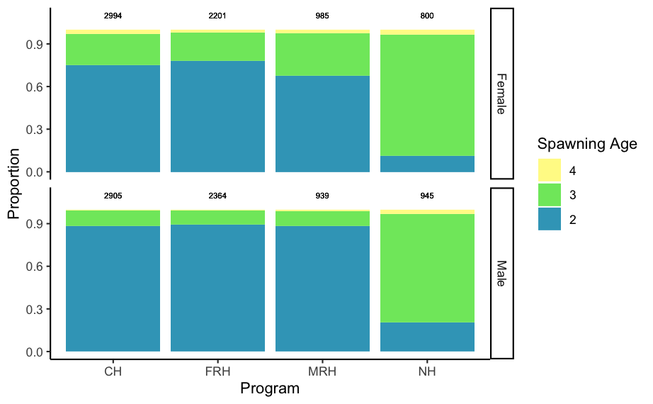

```r
age_sex_gg <- ggplot(age_sex_234)+
  geom_col(aes(x=PopName, y=freq, fill = as.factor(age_spawn)),
           position = position_fill(reverse = TRUE))+
  scale_fill_manual(values = c("#39a5c2","#7ee76c","#fff995"))+
  facet_grid(kid_sex~.)+
  theme_classic()+
  guides(fill = guide_legend(reverse = TRUE, title="Spawning Age"))+
  labs(x="Program", y="Proportion")+
  geom_text(aes(label=total, x=PopName, y=1.1), size = 2)
age_sex_gg
```

# Program Age at Spawning by Cohort and Return Year

## By Cohort (Release) Year

Kids will be grouped by cohort year to determine age structure thru years. Cohort year refers to the year that the kids were released as juveniles (SpawnYear)

```r
age_cohort <- age %>%
  group_by(PopName, SpawnYear) %>%
  count(age_spawn) %>%
  mutate(total = sum(n), freq = n/sum(n))
```

Kruskal-wallis: age_spawn ~ spawn_year

```r
options(digits = 7)
kruskal.test(age_cohort, age_spawn~SpawnYear)
```

```
    Kruskal-Wallis rank sum test

data:  age_cohort
Kruskal-Wallis chi-squared = 333.47, df = 5, p-value
< 2.2e-16
```

Kruskal-wallis: age_spawn by SpawnYear within each program

CH

```r
kruskal.test(age_cohort %>% filter(PopName == "CH"), age_spawn~SpawnYear)
```

```
    Kruskal-Wallis rank sum test

data:  age_cohort %>% filter(PopName == "CH")
Kruskal-Wallis chi-squared = 100.4, df = 5, p-value
< 2.2e-16
```

FRH

```r
kruskal.test(age_cohort %>% filter(PopName == "FRH"), age_spawn~SpawnYear)
```

```
    Kruskal-Wallis rank sum test

data:  age_cohort %>% filter(PopName == "FRH")
Kruskal-Wallis chi-squared = 89.021, df = 5, p-value
< 2.2e-16
```

MRH

```r
kruskal.test(age_cohort %>% filter(PopName == "MRH"), age_spawn~SpawnYear)
```

```
    Kruskal-Wallis rank sum test

data:  age_cohort %>% filter(PopName == "MRH")
Kruskal-Wallis chi-squared = 81.505, df = 5, p-value
= 4.064e-16
```

NH

```r
kruskal.test(age_cohort %>% filter(PopName == "NH"), age_spawn~SpawnYear)
```

```
    Kruskal-Wallis rank sum test

data:  age_cohort %>% filter(PopName == "NH")
Kruskal-Wallis chi-squared = 74.855, df = 5, p-value
= 9.976e-15
```

## By Return Year

Kids will be grouped by return/kid year to determine age structure thru years. Return year refers to the year that the kids returned to a hatchery to spawn (kid_year)

```r
age_ret <- age %>%
  group_by(PopName, kid_year) %>%
  count(age_spawn) %>%
  mutate(total = sum(n), freq = n/sum(n))
```

Kruskal-wallis: age_spawn ~ kid_year

```r
kruskal.test(age_ret, age_spawn~kid_year)
```

```
    Kruskal-Wallis rank sum test

data:  age_ret
Kruskal-Wallis chi-squared = 337.64, df = 5, p-value
< 2.2e-16
```

CH

```r
kruskal.test(age_ret %>% filter(PopName == "CH"), age_spawn~kid_year)
```

```
    Kruskal-Wallis rank sum test

data:  age_ret %>% filter(PopName == "CH")
Kruskal-Wallis chi-squared = 97.236, df = 5, p-value
< 2.2e-16
```

FRH

```r
kruskal.test(age_ret %>% filter(PopName == "FRH"), age_spawn~kid_year)
```

```
    Kruskal-Wallis rank sum test

data:  age_ret %>% filter(PopName == "FRH")
Kruskal-Wallis chi-squared = 98.992, df = 5, p-value
< 2.2e-16
```

MRH

```r
kruskal.test(age_ret %>% filter(PopName == "MRH"), age_spawn~kid_year)
```

```
    Kruskal-Wallis rank sum test

data:  age_ret %>% filter(PopName == "MRH")
Kruskal-Wallis chi-squared = 76.433, df = 5, p-value
= 4.671e-15
```

NH

```r
kruskal.test(age_ret %>% filter(PopName == "NH"), age_spawn~kid_year)
```

```
    Kruskal-Wallis rank sum test

data:  age_ret %>% filter(PopName == "NH")
Kruskal-Wallis chi-squared = 73.85, df = 5, p-value
= 1.616e-14
```

## Figure

```r
age_yr_fig1 <- age %>%
  group_by(PopName, SpawnYear) %>%
  count(age_spawn) %>%
  filter(age_spawn<5) %>%
  mutate(total = sum(n), freq = n/sum(n), type="Cohort Year") %>%
  rename("year"="SpawnYear", "hatchery"="PopName") %>%
  mutate(year = as.numeric(year))

age_yr_fig2 <- age %>%
  group_by(kid_hatchery, kid_year) %>%
  count(age_spawn) %>%
  filter(age_spawn<5) %>%
  mutate(total = sum(n), freq = n/sum(n), type="Return Year") %>%
  rename("year"="kid_year", "hatchery"="kid_hatchery") %>%
  mutate(year = as.numeric(year))

age_yr_fig <- rbind(age_yr_fig1, age_yr_fig2)
```

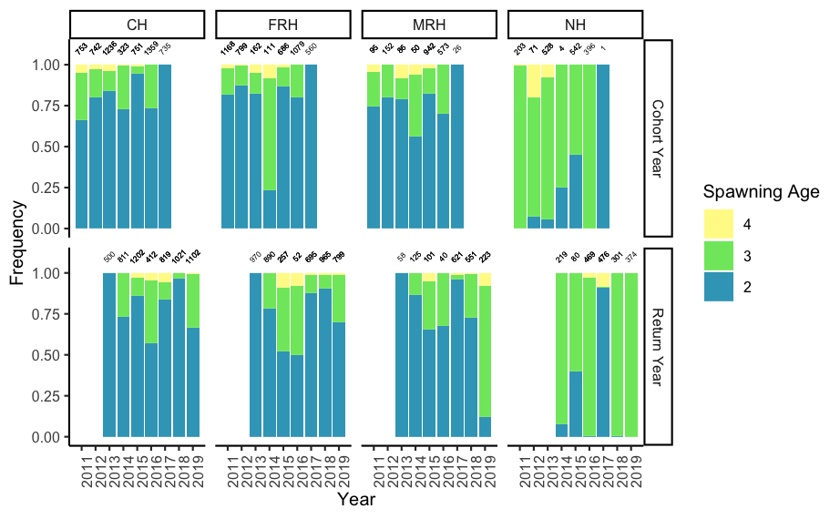

```r
age_yr_gg <- ggplot(age_yr_fig) +
  geom_col(aes(year, freq, fill = as.factor(age_spawn)),
           position = position_fill(reverse = TRUE)) +
  facet_grid(type ~hatchery) +
  scale_x_continuous(breaks = seq(2011, 2019, 1))+
  scale_y_continuous(breaks = seq(0,1,0.25))+
  guides(fill = guide_legend(reverse = TRUE, title="Spawning Age"))+
  scale_fill_manual(values = c("#39a5c2","#7ee76c","#fff995"))+
  theme_classic()+
  theme(text = element_text(size=10),
        axis.text.x = element_text(angle=90, hjust=1))+
  labs(x="Year", y="Frequency")+
  geom_text(aes(label=total, x=year, y=1.1), angle = 45, size = 1.5)

ggsave(plot=age_yr_gg, file="../figures/Fig2_age.png", width = 15, height = 10, units = "cm", dpi = 800)

age_yr_gg
```

# Program Age at Spawning - binned dates

Now, group spawners by binned spawn date by sex and age. Each program will have spawn dates grouped into sets of 5 dates across all spawn years, then programs will be scaled to 20 binned spawndates to standardize spawn length season. Binning spawn dates will line up dates to show ages by first bin of spawn dates for each hatchery. Julian dates have to be adjusted so that the spawn season dates are sequential chronologically for each season (some of them start in November or December, so need to have these dates first). Day of year (DOY) of 10 will be 11/09 instead of 01/10.

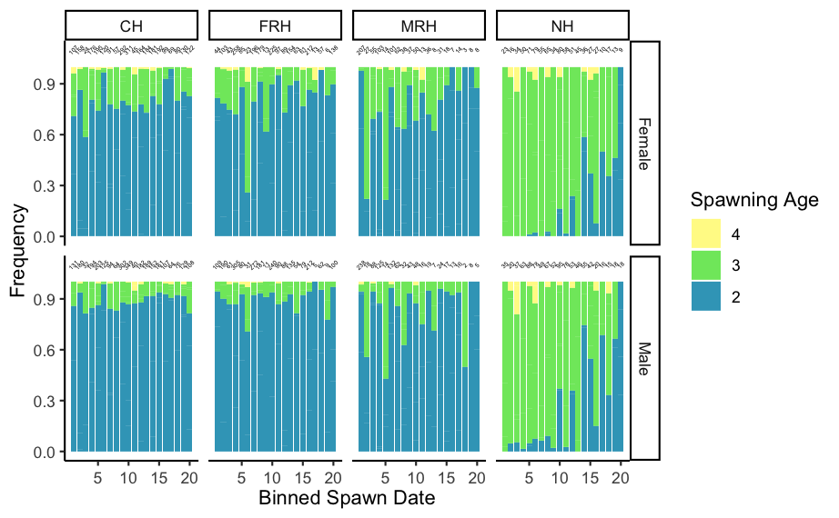

```r
bins_1 <- age %>%
  mutate(new_kid_sg = kid_sg, .after=kid) %>%
  separate_rows(new_kid_sg, sep=",") %>%
  group_by(kid) %>%
  filter(row_number()==1) %>%
  ungroup() %>%
  mutate(new_kid_sg = mdy(as.character(new_kid_sg))) %>%
  mutate(kid_ju = yday(new_kid_sg), .after=new_kid_sg) %>% # wanted to check that julian date / day o year same
  mutate(kid_dayofyear = (strftime(new_kid_sg, format = "%j")), .after=kid_ju) %>%
  mutate(kid_DOY = as.numeric(kid_dayofyear)-304) %>%
  mutate(kid_DOY = case_when(
    kid_DOY > 0 ~ kid_DOY,
    kid_DOY < 0 ~ kid_DOY + 365
  )) %>%
  filter(kid != "M097386") %>% # likely error in spawn date
  select(kid, ma, pa, kid_DOY, everything())
final_bins <- bins_1 %>%
  group_by(PopName) %>%
  filter(as.numeric(age_spawn)<5) %>%
  mutate(bin5 = cut_interval(kid_DOY, length=5, labels = F)) %>%
  mutate(bin_to_days = bin5 * 5) %>% # this part is so that bin to day ratio is there
  select(kid_DOY, bin5, bin_to_days, everything()) %>%
  count(kid_DOY, bin5, kid_sex, age_spawn) %>%
  group_by(kid_DOY, kid_sex) %>%
  mutate(frac.f = n/sum(n), total.f = sum(n))


day_bin <- final_bins %>%
  group_by(PopName) %>%
  distinct(kid_DOY) %>%
  group_by(PopName) %>%
  mutate(day_id = row_number(),
         day_bin = cut(day_id,20,labels=F))

final_beens <- left_join(final_bins, day_bin, by=c("PopName","kid_DOY")) %>%
  group_by(PopName, day_bin, kid_sex) %>%
  mutate(freq = n/sum(n), total = sum(n))

bins_gg <- ggplot(final_beens %>% filter(age_spawn <5))+
  geom_col(aes(x = day_bin, y = freq, fill = as.factor(age_spawn)), position = position_fill(reverse = TRUE))+
  scale_fill_discrete(limits=c(4,3,2))+
  facet_grid(kid_sex~PopName)+
  theme_classic()+
  scale_fill_manual(values = c("#39a5c2","#7ee76c","#fff995"))+
  guides(fill = guide_legend(reverse = TRUE, title="Spawning Age"))+
  labs(x = "Binned Spawn Date", y = "Frequency")+
  geom_text(aes( x = day_bin, y=1.1, label=total), stat = 'unique', size = 1.2, angle=45)+
  theme(axis.text.x = element_text(vjust = 0.5))+
  scale_x_continuous(breaks = seq(5,20,5))
bins_gg

ggsave(plot=bins_gg, file="../figures/Fig3_bins.png", width = 20, height = 10, units = "cm", dpi = 800)
```

## Spawn season lengths

```r
final_fig3_bin <- bins_1 %>%
 filter(as.numeric(age_spawn)<5) %>%
  mutate(bin5 = cut_interval(kid_DOY, length = 5, labels = F)) %>%
  mutate(bin_to_days = bin5 * 5) %>%
  select(kid_DOY, bin5, bin_to_days, everything()) %>%
  count(bin_to_days, PopName) %>%
  group_by(bin_to_days, PopName) %>%
  mutate(frac = n/sum(n), total = sum(n))
```

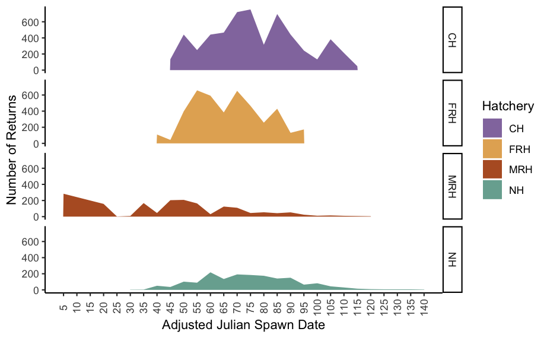

```r
fig1add <- ggplot(final_fig3_bin)+
  geom_area(aes(x = bin_to_days, y = n, fill = as.factor(PopName)))+
  facet_grid(PopName ~.)+
  theme_classic()+
  scale_fill_manual(values =c("#9379AD", "#e4af62", "#b65d2b", "#79ad9f"))+
  labs(x = "Adjusted Julian Spawn Date", fill = "Hatchery", y = "Number of Returns")+
  scale_x_continuous(breaks = seq(5,140,5))+
  theme(axis.text.x = element_text(angle = 90, vjust = 0.5))
fig1add
```

```r
ggsave(plot = fig1add, file = "../figures/S1_spwnsn.png",
       width = 25, height = 10, units = "cm", dpi = 800)
```